# Course Project: PML

September 27, 2015

## Introduction

In this project, the goal is to use data from accelerometers on the belt, forearm, arm, and dumbell of 6 participants. The participants were asked to perform barbell lifts correctly and incorrectly in 5 different ways. More information is available from the website here: http://groupware.les.inf.puc-rio.br/har

Reference to the paper on this dataset: Velloso, E.; Bulling, A.; Gellersen, H.; Ugulino, W.; Fuks, H. Qualitative Activity Recognition of Weight Lifting Exercises. Proceedings of 4th International Conference in Cooperation with SIGCHI (Augmented Human ’13) . Stuttgart, Germany: ACM SIGCHI, 2013

Read more: http://groupware.les.inf.puc-rio.br/har#weight_lifting_exercises#ixzz3mv0Vy4KT

## Data

```r
# Load train data
trainURL <- "https://d396qusza40orc.cloudfront.net/predmachlearn/pml-training.csv"
trainData <- read.csv(url(trainURL), na.strings=c("NA","#DIV/0!",""))
dim(trainData)
```

```
## [1] 19622   160
```

```r
# Load test data
testURL <- "https://d396qusza40orc.cloudfront.net/predmachlearn/pml-testing.csv"
testData <- read.csv(url(testURL), na.strings=c("NA","#DIV/0!",""))
dim(testData)
```

```
## [1]  20 160
```

## Preparing the dataset

#### Remove correlated variables

```r
require(caret)
rm_cols <- findCorrelation(x=cor(trainData[,-53]), cutoff = .9, verbose = F)
goodVars <- goodVars[-rm_cols]
trainData <- trainData[goodVars]
dim(trainData)
```

```
## [1] 19622    46
```

#### Final set of variables

```r
colNames <- colnames(trainData[,-46])
colNames
```

```
##  [1] "pitch_belt"           "yaw_belt"             "total_accel_belt"
##  [4] "gyros_belt_x"         "gyros_belt_y"         "gyros_belt_z"
##  [7] "magnet_belt_x"        "magnet_belt_y"        "magnet_belt_z"
## [10] "roll_arm"             "pitch_arm"            "yaw_arm"
## [13] "total_accel_arm"      "gyros_arm_y"          "gyros_arm_z"
## [16] "accel_arm_x"          "accel_arm_y"          "accel_arm_z"
## [19] "magnet_arm_x"         "magnet_arm_y"         "magnet_arm_z"
## [22] "roll_dumbbell"        "pitch_dumbbell"       "yaw_dumbbell"
## [25] "total_accel_dumbbell" "gyros_dumbbell_y"     "accel_dumbbell_x"
## [28] "accel_dumbbell_y"     "accel_dumbbell_z"     "magnet_dumbbell_x"
## [31] "magnet_dumbbell_y"    "magnet_dumbbell_z"    "roll_forearm"
## [34] "pitch_forearm"        "yaw_forearm"          "total_accel_forearm"
## [37] "gyros_forearm_x"      "gyros_forearm_y"      "gyros_forearm_z"
## [40] "accel_forearm_x"      "accel_forearm_y"      "accel_forearm_z"
## [43] "magnet_forearm_x"     "magnet_forearm_y"     "magnet_forearm_z"
```

```r
#names(testData)
testData <- testData[colNames];dim(testData)
```

```
## [1] 20 45
```

## Training data for Prediction

Before we using the full training dataset, we will partition the training set to evalate the accuracy & errors.

### Partioning the training data

```r
inTrain <- createDataPartition(y=trainData$classe, p=.75, list=FALSE)
myTrainData <- trainData[inTrain,]; dim(myTrainData)
```

```
## [1] 14718    46
```

```r
myTestData <- trainData[-inTrain,]; dim(myTestData)
```

```
## [1] 4904   46
```

## Model Selection

### Fitting the model using decision tree method

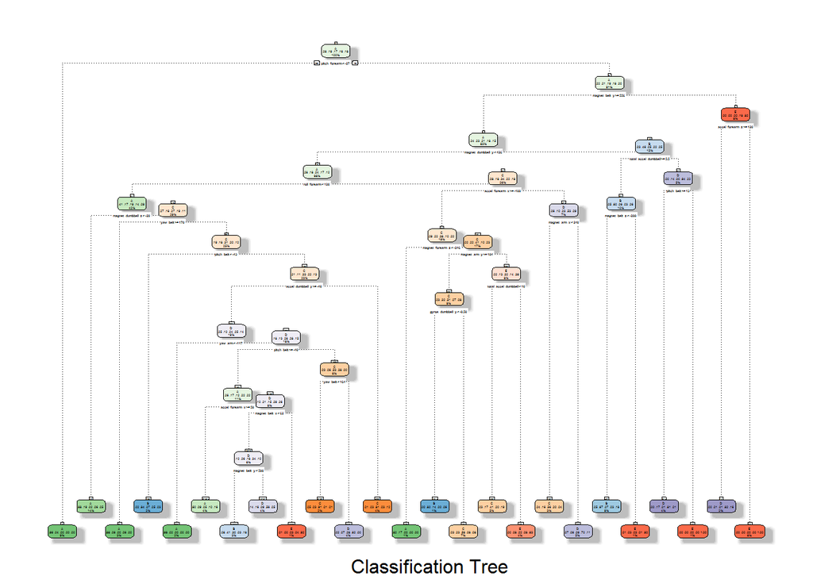

```r
require(rpart)
require(rpart.plot)
require(RColorBrewer)
require(rattle)

set.seed(2015)
myFit <- rpart(classe ~ ., data=myTrainData, method="class")
fancyRpartPlot(myFit, sub = "Classification Tree")
```

```r
myPred <- predict(myFit, myTestData, type = "class")
confusionMatrix(myPred, myTestData$classe)
```

```
## Confusion Matrix and Statistics
##
##           Reference
## Prediction    A    B    C    D    E
##          A 1258  224   21   83   75
##          B   57  496   78   20  122
##          C   31  128  614   96  105
##          D   40   85   92  585   56
##          E    9   16   50   20  543
##
## Overall Statistics
##
##                Accuracy : 0.7129
##                  95% CI : (0.7, 0.7255)
##     No Information Rate : 0.2845
##     P-Value [Acc > NIR] : < 2.2e-16
##
##                   Kappa : 0.6347
##  Mcnemar's Test P-Value : < 2.2e-16
##
## Statistics by Class:
##
##                      Class: A Class: B Class: C Class: D Class: E
## Sensitivity            0.9018   0.5227   0.7181   0.7276   0.6027
## Specificity            0.8852   0.9300   0.9111   0.9334   0.9763
## Pos Pred Value         0.7574   0.6417   0.6304   0.6818   0.8511
## Neg Pred Value         0.9578   0.8903   0.9387   0.9459   0.9161
## Prevalence             0.2845   0.1935   0.1743   0.1639   0.1837
## Detection Rate         0.2565   0.1011   0.1252   0.1193   0.1107
## Detection Prevalence   0.3387   0.1576   0.1986   0.1750   0.1301
## Balanced Accuracy      0.8935   0.7263   0.8146   0.8305   0.7895
```

The accuracy is not very good, it less than 80%.

### Fitting model using Random Forests method

```r
library(caret)
# Train using 3-fold cross validation
fit2Control <- trainControl(method="cv", number=3, verboseIter=F)
fit2 <- train(classe ~ ., data=myTrainData, method="rf", trControl=fit2Control)
fit2$finalModel
```

```
##
## Call:
##  randomForest(x = x, y = y, mtry = param$mtry)
##                Type of random forest: classification
##                      Number of trees: 500
## No. of variables tried at each split: 23
##
##         OOB estimate of  error rate: 0.54%
## Confusion matrix:
##      A    B    C    D    E  class.error
## A 4181    4    0    0    0 0.0009557945
## B   19 2824    5    0    0 0.0084269663
## C    0   11 2549    6    1 0.0070120764
## D    0    1   20 2387    4 0.0103648425
## E    0    0    3    6 2697 0.0033259424
```

```r
preds2 <- predict(fit2, newdata=myTestData)
confusionMatrix(myTestData$classe, preds2)
```

```
## Confusion Matrix and Statistics
##
##           Reference
## Prediction    A    B    C    D    E
##          A 1392    2    0    0    1
##          B    7  939    3    0    0
##          C    0    2  847    6    0
##          D    0    0   12  792    0
##          E    0    0    0    6  895
##
## Overall Statistics
##
##                Accuracy : 0.992
##                  95% CI : (0.9891, 0.9943)
##     No Information Rate : 0.2853
##     P-Value [Acc > NIR] : < 2.2e-16
##
##                   Kappa : 0.9899
##  Mcnemar's Test P-Value : NA
##
## Statistics by Class:
##
##                      Class: A Class: B Class: C Class: D Class: E
## Sensitivity            0.9950   0.9958   0.9826   0.9851   0.9989
## Specificity            0.9991   0.9975   0.9980   0.9971   0.9985
## Pos Pred Value         0.9978   0.9895   0.9906   0.9851   0.9933
## Neg Pred Value         0.9980   0.9990   0.9963   0.9971   0.9998
## Prevalence             0.2853   0.1923   0.1758   0.1639   0.1827
## Detection Rate         0.2838   0.1915   0.1727   0.1615   0.1825
## Detection Prevalence   0.2845   0.1935   0.1743   0.1639   0.1837
## Balanced Accuracy      0.9971   0.9966   0.9903   0.9911   0.9987
```

### Using the full training dataset with Random Forests method

```r
# Train using 3-fold cross validation
fit3Control <- trainControl(method="cv", number=3, verboseIter=F)
fit3 <- train(classe ~ ., data=trainData, method="rf", trControl=fit3Control)
fit3$finalModel
```

```
##
## Call:
##  randomForest(x = x, y = y, mtry = param$mtry)
##                Type of random forest: classification
##                      Number of trees: 500
## No. of variables tried at each split: 23
##
##         OOB estimate of  error rate: 0.44%
## Confusion matrix:
##      A    B    C    D    E class.error
## A 5573    5    1    0    1 0.001254480
## B   17 3772    8    0    0 0.006584145
## C    0    9 3405    8    0 0.004967855
## D    0    0   24 3190    2 0.008084577
## E    0    0    3    8 3596 0.003049626
```

```r
preds3 <- predict(fit3, newdata=testData)
```

### Create files for submission

```r
preds_out <- as.character(preds3)

pml_write_files <- function(x) {
    n <- length(x)
    for(i in 1:n) {
        filename <- paste0("problem_id_", i, ".txt")
        write.table(x[i], file=filename, quote=F, row.names=F, col.names=F)
    }
}

pml_write_files(preds_out)
```